# Project

### Problem Statement

In the year 2013, a supermarket decided to draw insight from their data in order to make data driven decisions. As a Data Analyst,you are presented with their 2013 daily sales records (sales_data.csv) and tasked to help them find answers to the questions below by analysing the data.

1. i. What is the average sales and profit per market?

   ii.Plot a stacked bar chart showing the sales and profit per market.

   iii.Which market brings more sales on the average?
2. i. What are the best 10 performing products with regards to sales in 2013?

   ii.What are the least 10 performing products with regards to sales 2013?
1. i. Extract the days and months from the Order Date and add them to the data frame with the name "Days" and "Months" respectively?

   ii.Show the trend of profit from January to December with a line plot.

   iii. Which month does the company make more profit and what 5 products are sold most in that month? iv. which day does the company make high sales on the average?
2. i. By analyzing the data, what is the correlation between sales and discount?

   ii. Use a scatter plot to show the relationship between sales and profit.
3. i. Plot a grouped bar chart showing the total profit for the different product category for each market. ii. From your graph, which product category performs well in each market?
4. i. Which customer spent the most in the whole year? ii. What product does the customer in (i) buy the most? iii. Which month did the customer spent the most? iv. How much did this customer spend in the whole year?
5. Can you do any other analysis to draw more insight? Feel free to do it.

**Thank you**

**GOOD LUCK!**

```python
# Use markdowns to write your answers or findings where necessary.
# Use comments to exlain you codes where necessary
# Remember to import the necessary packages
```

```python
import pandas as pd
import numpy as nd
import matplotlib.pyplot as plt
```

### **NB**: To easily load the data, it's advisable you have the data and the notebook file in the same folder

```python
df=pd.read_csv('sales_data.csv')
df.head()
```

|  | Unnamed: 0 | Order Date | Order ID | Customer ID | Customer Name | Segment | City | Market | Region | Category | Sub-Category | Product Name | Sales | Quantity | Discount | Profit |
| --- | --- | --- | --- | --- | --- | --- | --- | --- | --- | --- | --- | --- | --- | --- | --- | --- |
| 0 | 0 | 2013-01-01 | ID-2013-37383 | MY-18295 | Muhammed Yedwab | Corporate | Albury | APAC | Oceania | Technology | Copiers | Canon Copy Machine, Digital | 1649.214 | 7 | 0.1 | 36.624 |
| 1 | 1 | 2013-01-01 | IN-2013-47960 | JE-15715 | Joe Elijah | Consumer | Tianjin | APAC | North Asia | Furniture | Bookcases | Sauder Floating Shelf Set, Metal | 1358.280 | 7 | 0.0 | 203.700 |
| 2 | 2 | 2013-01-01 | ID-2013-37383 | MY-18295 | Muhammed Yedwab | Corporate | Albury | APAC | Oceania | Technology | Accessories | Logitech Memory Card, Erganomic | 728.568 | 8 | 0.1 | -32.472 |
| 3 | 3 | 2013-01-01 | IN-2013-47960 | JE-15715 | Joe Elijah | Consumer | Tianjin | APAC | North Asia | Furniture | Bookcases | Dania Library with Doors, Mobile | 2189.520 | 6 | 0.0 | 372.060 |
| 4 | 4 | 2013-01-01 | IN-2013-47960 | JE-15715 | Joe Elijah | Consumer | Tianjin | APAC | North Asia | Furniture | Bookcases | Sauder Floating Shelf Set, Traditional | 1362.060 | 7 | 0.0 | 340.410 |

1i. Average sales and profit per market

```python
df_grouped = df.groupby('Market').mean()[['Sales','Profit']]
df_grouped
```

| Market | Sales | Profit |
| --- | --- | --- |
| APAC | 337.225210 | 42.596237 |
| Africa | 177.023796 | 20.623734 |
| Canada | 180.765566 | 48.391132 |
| EMEA | 156.453122 | 8.102479 |
| EU | 297.415215 | 38.373754 |
| LATAM | 198.738815 | 20.070383 |
| US | 235.842570 | 31.677105 |

1ii) A stacked bar chart showing average sales and profit per market

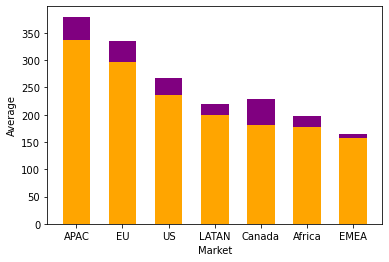

```python
# define sales
market= ["APAC","EU","US","LATAN","Canada","Africa","EMEA"]
sales= [337.2, 297.4, 235.8, 198.7, 180.8, 177.0, 156.5]
profit= [42.6, 38.4, 31.7, 20.1, 48.4, 20.6, 8.1]
# #width of stacked chart
w=0.6
#plot stacked chart
plt.bar (market, sales, w, color='Orange')
plt.bar (market, profit, w, color='Purple',
bottom= sales)
#labels
plt.xlabel('Market')
plt.ylabel('Average')
#display
plt.show()
```

1iii) Market that bring more sales on the average is APAC

```python
df.groupby(['Market']).mean()[['Sales']].sort_values("Sales", ascending=False).head(1)
```

| Market | Sales |
| --- | --- |
| APAC | 337.22521 |

2i) 10 best performing products in regard to sales

```python
df.groupby(['Product Name']).sum()[['Sales']].sort_values("Sales", ascending=False).head(10)
```

| Product Name | Sales |
| --- | --- |
| Motorola Smart Phone, Full Size | 29357.0982 |
| Cisco Smart Phone, Full Size | 26737.1330 |
| Canon imageCLASS 2200 Advanced Copier | 25899.9260 |
| Harbour Creations Executive Leather Armchair, Adjustable | 21871.1296 |
| Apple Smart Phone, Full Size | 21120.4080 |
| Hon Executive Leather Armchair, Adjustable | 20104.6026 |
| Office Star Executive Leather Armchair, Adjustable | 19936.1460 |
| Nokia Smart Phone, with Caller ID | 18568.8543 |
| Samsung Smart Phone, VoIP | 16733.1120 |
| Nokia Smart Phone, Full Size | 14765.8800 |

2ii) 10 least performing products in regard to sales

```python
df.groupby(['Product Name']).sum()[['Sales']].sort_values("Sales", ascending=False).tail(10)
```

| Product Name | Sales |
| --- | --- |
| Crayola Anti Dust Chalk, 12/Pack | 2.912 |
| Newell 32 | 2.880 |
| Eldon Spacemaker Box, Quick-Snap Lid, Clear | 2.672 |
| Acco 3-Hole Punch | 2.628 |
| Avery 479 | 2.610 |
| Acco Banker's Clasps, 5 3/4"-Long | 2.304 |
| Maxell 4.7GB DVD+R 5/Pack | 1.980 |
| Avery Durable Binders | 1.728 |
| OIC #2 Pencils, Medium Soft | 1.504 |
| Newell 310 | 1.408 |

3i) Extract days and months from order date

```python
#EXtract days from the order date column
df['Days']=pd.DatetimeIndex(df['Order Date']).day
#EXtract month_no from the order date column
df['MonthNO']=pd.DatetimeIndex(df['Order Date']).month
#EXtract months from the order date column
df['Months']=pd.DatetimeIndex(df['Order Date']).month_name()
#To check new columns added
df.head()
```

|  | Unnamed: 0 | Order Date | Order ID | Customer ID | Customer Name | Segment | City | Market | Region | Category | Sub-Category | Product Name | Sales | Quantity | Discount | Profit | Days | Months | MonthNO |
| --- | --- | --- | --- | --- | --- | --- | --- | --- | --- | --- | --- | --- | --- | --- | --- | --- | --- | --- | --- |
| 0 | 0 | 2013-01-01 | ID-2013-37383 | MY-18295 | Muhammed Yedwab | Corporate | Albury | APAC | Oceania | Technology | Copiers | Canon Copy Machine, Digital | 1649.214 | 7 | 0.1 | 36.624 | 1 | January | 1 |
| 1 | 1 | 2013-01-01 | IN-2013-47960 | JE-15715 | Joe Elijah | Consumer | Tianjin | APAC | North Asia | Furniture | Bookcases | Sauder Floating Shelf Set, Metal | 1358.280 | 7 | 0.0 | 203.700 | 1 | January | 1 |
| 2 | 2 | 2013-01-01 | ID-2013-37383 | MY-18295 | Muhammed Yedwab | Corporate | Albury | APAC | Oceania | Technology | Accessories | Logitech Memory Card, Erganomic | 728.568 | 8 | 0.1 | -32.472 | 1 | January | 1 |
| 3 | 3 | 2013-01-01 | IN-2013-47960 | JE-15715 | Joe Elijah | Consumer | Tianjin | APAC | North Asia | Furniture | Bookcases | Dania Library with Doors, Mobile | 2189.520 | 6 | 0.0 | 372.060 | 1 | January | 1 |
| 4 | 4 | 2013-01-01 | IN-2013-47960 | JE-15715 | Joe Elijah | Consumer | Tianjin | APAC | North Asia | Furniture | Bookcases | Sauder Floating Shelf Set, Traditional | 1362.060 | 7 | 0.0 | 340.410 | 1 | January | 1 |

3ii) Trend of profits from january to december

```python
#EXtract month number from the order date column
df['MonthNO']=pd.DatetimeIndex(df['Order Date']).month
```

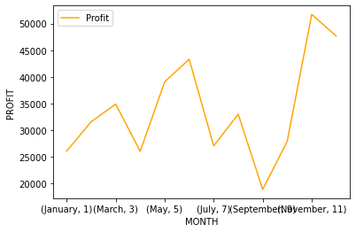

```python
df.groupby(['Months','MonthNO']).sum()[['Profit']].sort_values('MonthNO', ascending=True).plot.line(color="orange")
#labels
plt.xlabel('MONTH')
plt.ylabel('PROFIT')
#display
plt.show()
```

3iii) Month with more profit = November

5 products sold most in the month

```python
#Month with highest profit
df.groupby(['Months']).sum()[['Profit']].sort_values("Profit", ascending=False).head(1)
```

| Months | Profit |
| --- | --- |
| November | 51720.88568 |

```python
#5 products sold most in November
df.loc[df['Months'] == 'November'].groupby(['Product Name']).sum()[['Sales']].sort_values("Sales", ascending=False).head(5)
```

| Product Name | Sales |
| --- | --- |
| Cisco Smart Phone, Full Size | 5869.820 |
| SAFCO Executive Leather Armchair, Black | 5370.300 |
| KitchenAid Stove, Red | 4618.215 |
| Tenex Lockers, Wire Frame | 4531.806 |
| Cubify CubeX 3D Printer Double Head Print | 4499.985 |

3iv) Day company make highest sales on the average = DAY 2

```python
df.groupby(['Days']).mean()[['Sales']].sort_values("Sales", ascending=False).head(1)
```

| Days | Sales |
| --- | --- |
| 2 | 318.411526 |

4i) Correlation between sales and discount

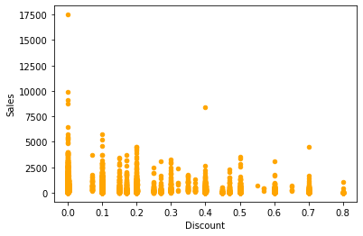

```python
df.plot(x="Discount", y="Sales", kind="scatter", c='orange')
```

4ii) Scatter plot to show the relationship between sales and profit

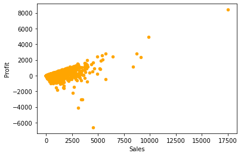

```python
df.plot.scatter('Sales','Profit', c='orange')
```

5i) Group bar chart showing showing total profit for each category of market

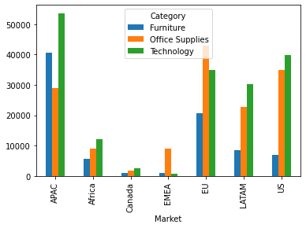

```python
df_pivot = pd.pivot_table(
    df, values="Profit",index="Market",columns="Category", aggfunc= sum
)
ax=df_pivot.plot(kind="bar")
```

5ii) Product category that perform well in each market

1. In APAC, Africa, Canada, LATAM, US - Technology perform well
2. In EMEA, EU -Office supplies perform well

6i) Customer that spent the most in the whole year = TAMARA CHAND

```python
#Month with highest profit
df.groupby(['Customer Name','Customer ID']).sum()[['Sales']].sort_values("Sales", ascending=False).head(1)
```

| Customer Name | Customer ID | Sales |
| --- | --- | --- |
| Tamara Chand | TC-20980 | 23036.988 |

6ii) Product that Tamara buy the most = Canon imageCLASS 2200 Advanced Copier

```python
df.loc[df['Customer Name'] == 'Tamara Chand'].groupby(['Product Name']).sum()[['Sales']].sort_values("Sales", ascending=False).head(1)
```

| Product Name | Sales |
| --- | --- |
| Canon imageCLASS 2200 Advanced Copier | 17499.95 |

6iii) Month the customer spent the most = March

```python
df.loc[df['Customer Name'] == 'Tamara Chand'].groupby(['Months']).sum()[['Sales']].sort_values("Sales", ascending=False).head(1)
```

| Months | Sales |
| --- | --- |
| March | 18336.74 |

6iv) Total amount Tamara spend in the whole year

```python
df.loc[df['Customer Name'] == 'Tamara Chand'].sum()[['Sales']]
```

```
Sales    23190.408
dtype: object
```